# Concurrent validity of an Estimator of Weekly Alcohol Consumption (EWAC) based on the Extended AUDIT

# Abstract

**Background and Aims:** The 3-question Alcohol Use Disorders Identification Test (AUDIT-C) is frequently used in healthcare for screening and brief advice about levels of alcohol consumption. AUDIT-C scores (0–12) provide feedback as categories of risk rather than estimates of actual alcohol intake, an important metric for behaviour change. The study aimed to (a) develop a continuous metric from the Extended AUDIT-C expressed in UK units (8g pure ethanol), offering equivalent accuracy, and providing a direct estimator of weekly alcohol consumption (EWAC); (b) evaluate the EWAC’s bias and error using the Graduated-Frequency (GF) questionnaire as a reference standard of alcohol consumption.

**Design:** Cross-sectional diagnostic study based on a nationally-representative survey.

**Settings:** Community-dwelling households in England.

**Participants:** 22,404 household residents aged $\geq$ 16 years reporting drinking alcohol at least occasionally.

**Measurements:** Computer-assisted personal interviews consisting of (a) AUDIT questionnaire with extended response items (the ‘Extended AUDIT’) and (b) GF. Primary outcomes were: mean deviation <1 UK unit (metric of bias); root mean squared deviation <2 UK units (metric of total error) between EWAC and GF. The secondary outcome was the receiver operating characteristic area under the curve for predicting alcohol consumption in excess of 14 and 35 UK units.

**Findings:** EWAC had a positive bias of 0.2 UK units [95% confidence interval: 0.08, 0.4] compared to GF. Deviations were skewed: while the mean error was ±11 UK units/week [9.5, 11.9], in half of participants the deviation between EWAC and GF was between 0 and ±2.1 UK units/week. EWAC predicted consumption in excess of 14 UK units/week with a significantly greater area under the curve (0.918 [0.914, 0.923]) than AUDIT-C (0.870 [0.864, 0.876]) or the full AUDIT (0.854 [0.847, 0.860]).

**Conclusions:** The EWAC https://ewac.netlify.app is designed to estimate weekly alcohol consumption using answers to the Extended AUDIT-C. The EWAC meets the targeted bias tolerance. It is superior in accuracy to AUDIT-C and the full AUDIT when predicting consumption thresholds, making it a reliable complement to the Extended AUDIT-C for health promotion interventions.

# Keywords

alcohol consumption; self report; alcohol use disorder; screening programs, diagnostic; preventive health services

# Introduction

Alcohol consumption is responsible for 5% of disability-adjusted life years [1]. This burden extends far beyond the health burden of *alcohol use disorders*, as defined in the International Statistical Classification of Diseases (ICD-10 F10.1/F10.2 [2]) or the Diagnostic and Statistical Manual of Mental Disorders [3]. Clinical guidelines aiming to prevent [4], treat and reduce [5] harm from alcohol consumption recommend systematic screening for alcohol consumption using validated clinical tools. However, conceptual differences (exemplified by the diagnostic classifications above) remain in how best to diagnose, measure, and communicate harm [6].

A global standard has emerged in the 10-item Alcohol Use Disorders Identification Test (AUDIT) [7]. The shorter 3-item AUDIT-C focusses on consumption, and has equivalent predictive capability [8]. AUDIT-C is easy to use, making it an attractive choice for alcohol screening and brief interventions in healthcare [9] and other settings [10]. AUDIT-C exhibits two characteristics:

The present study proposes to address the second of these characteristics. It aims to develop and validate an Estimator of Weekly Alcohol Consumption (EWAC) computed from the Extended AUDIT-C. While retaining the Extended AUDIT-C questionnaire’s alcohol use disorders diagnostic capabilities, the EWAC is intended to facilitate the delivery of screening and brief interventions by converting Extended AUDIT-C responses into a continuous and direct measure of alcohol consumption that does not require additional screening questions. Measuring alcohol consumption is a crucial part of behaviour change techniques (self-monitoring, feedback on behaviour, social comparison) commonly employed in self- [10] and clinician-administered [9,24] interventions, and is encouraged as a metric of the continuum of alcohol use [19].

# Methods

## Participants

Data originate from baseline measures in waves 110–133 (November 2015–October 2017) of the Alcohol Toolkit Study, a repeated cross-sectional survey of residents of private English households aged $\geq$ 16 years. Each month, census output areas averaging 300 households were selected by stratified random sampling. Interviewers travelled to their designated area and approach households quota sampling [23]. Respondents participated in a computer-assisted personal interview.

## Measures

Index measurements underpinning the EWAC were the three questions making up the Extended AUDIT-C (supplementary information S2), in which participants described their drinking *during the last 6 months*.

The reference standard used is the Alcohol Toolkit Study GF schedule (supplementary information S3), in which participants described how many times they consumed given quantities of alcohol *during the last 4 weeks* [25]. The GF schedule’s main advantage lies in measuring occasional heavy consumption, which can constitute an important proportion of total consumption.

Other reference estimates were used, this time for aggregate comparisons. 2014 per-capita alcohol retail sales [26] captured all alcohol produced/processed in or imported to England for sale or consumption. We also used data from 6,606 household residents aged $\geq$ 18 years participating in the 2011 Health Survey for England [27]. Year 2011 was chosen in deviation from the registered protocol [28]: on that particularly year, the recurring computer-assisted interviewer-led beverage-specific quantity-frequency questionnaire was accompanied by a prospective 7-day diary [29]. The diary reference standard was deemed more informative to an international audience, and offered a direct point of comparison with past research [30–32].

## Estimating alcohol consumption (EWAC)

To estimate alcohol consumption from Extended AUDIT-C responses, we employ methods developed for quantity-frequency-variability instruments [33]. For every individual $i$, the EWAC is computed as the product of $F_i$ and $Q_i$ (AUDIT questions 1 and 2 respectively) adjusted with the frequency of intense drinking $V_i$ (AUDIT-3):

$$\text{EWAC}_i = F_i Q_i + V_ib$$

where $b$ denotes the average units of alcohol consumed in an intense drinking day.

Coefficients $F, Q, V$ and $b$ are unknown. In this study, two sets of candidate coefficients are considered:

- AUDIT response item interval midpoint (e.g. 2.5 for ‘2 to 3 times per week’)
- coefficients estimated empirically from a sample of individuals with measurements of Extended AUDIT-C and GF, using a hierarchical Bayesian response model with the estimating equation $\text{GF}_i = F_i Q_i + V_ib + e_i$, where $e$ denotes independently normally distributed errors. We set parabola-shaped informative priors on coefficients $F, Q, V$. Details on model fitting, convergence evaluation and prior tuning are reported in supplementary information S1.

## Analyses

The protocol was pre-registered [28]. Results are reported in UK alcohol units (8g or 10mL of pure alcohol). Analyses were conducted in `R` [34–36] and all computer scripts are available online [37].

Participants were included in the analysis if they completed both the Extended AUDIT and the GF questionnaires. Out of 40,832 participants, 14,408 (35%) reported ‘never’ consuming alcohol in AUDIT question 1 and were not asked any further AUDIT or GF questions. A further 175 (0.4%) did not have valid AUDIT-C answers. Finally, 3,876 participants (9%) who did not have a valid GF alcohol consumption record were excluded. These GF data were assumed to be missing at random conditionally on the Extended AUDIT-C responses after a sensitivity analysis (supplementary information S1).

Valid observations (*N*=22,373) were separated into two datasets:

- The training dataset (*N*=6,642) consisted of a 30 percent subset of participants drawn using stratified random sampling, ensuing a balanced representation by sex, age, ethnic group and AUDIT-C risk level. It was used to estimate coefficients underpinning the EWAC (supplementary information S1).
- The validation dataset consisted of the remaining participants (*N*=15,731) and was used to evaluate the EWAC’s bias and precision. In subgroup validation analyses utilising additional variables (eg education, smoking status), a further 358/15,731 observations (2.3%) assumed to be missing at random were excluded.

### Overall bias and error

The agreement between the EWAC and the GF was quantified in the validation dataset:

### Subgroup bias and error

Multivariate regression models tested whether the EWAC’s bias and precision varied across population subgroups:

- the simple deviation $(\text{EWAC}-\text{GF})$ was regressed in a linear model to test subgroup differences in MD
- the squared deviation $(\rm{EWAC}-\rm{GF})^2$ was regressed in a log-transformed linear model to test subgroup differences in the geometric mean squared deviation. Model coefficients were then back-transformed (square root of the exponential) into relative RMSD estimates; these are interpreted as the ratio of the subgroup RMSD to the reference RMSD, a ratio >1 indicating worse precision than in the reference category.

Both models (supplementary table S5.1) included the following predictors: sex by age group; ethnic group; highest educational qualification; religion; smoking status. Additional models (supplementary table S5.2) were fitted solely in respondents with an AUDIT-C score $\geq$ 5 or an AUDIT score $\geq$ 8, for whom additional characteristics were recorded during interview: favourite drink (beer; wine; spirits alone; mixed spirits; cider; other); and whether the respondent had attempted to restrict alcohol intake in the last 12 months.

### Receiver Operating Characteristics

We tested the EWAC’s superiority to the traditional AUDIT and AUDIT-C scores in predicting consumption exceeding 14 or 35 UK units/week. These correspond to UK thresholds for characterising alcohol use as ‘increasing risk’ (predicted by an AUDIT-C score of 5–7), and ‘higher risk’ (AUDIT-C score $\geq$ 8) which is above 35 units for women and 50 units for men [38]. We tested the hypothesis that the EWAC has an identical receiver operating characteristic full area under the curve (AUC) to the AUDIT-C and the full AUDIT scores using nonparametric paired AUC tests [39]. AUDIT-C and AUDIT scores were calculated from the Extended AUDIT by capping the contribution of each question to 4.

### Aggregate concurrent validity

We compared the empirical cumulative distributions of (1) the EWAC computed in the Alcohol Toolkit Study; (2) the GF estimator in the Alcohol Toolkit Study; (3) the beverage-specific estimator in the 2011 Health Survey for England; (4) the prospective diary estimator in the 2011 Health Survey for England in adults aged $\geq$ 18 years. A $\chi^2$ test of homogeneity of distributions (1) and (3) was performed on contingency tables of 13 drinking consumption intervals in UK units/week (]0,5]; ]5,10]; …; ]30,35]; ]35,45]; ]45,55]; ]55,65]; ]65,75]; ]75,100]; ]100,200]). We report the proportions of on-trade and off-trade alcohol sales [26] accounted for by each method.

Poststratification survey weights adjusted for nonresponse bias in sources (1-3), and self-selection into prospective diary data collection in source (4).

# Results

## Bias and precision

EWAC coefficients estimated empirically (supplementary information S1, S4) had smaller bias and error and were used for the remainder of the analysis. With those, the EWAC’s Pearson’s correlation with GF was estimated at $r$ = 0.72 [0.71, 0.72] (Kendall’s rank correlation $\tau$ = 0.63).

The mean deviation (MD) was 0.2 alcohol units/week [95% CI: 0.08, 0.4]. This bias is smaller than the preregistered $\pm$ 1-unit bias tolerance ($p$ = 1.000).

The root mean squared deviation (RMSD), at 10.7 units/week [95% CI: 9.5, 11.9], was significantly greater than the pre-registered 2-unit total error tolerance ($p$ < 0.001), suggesting that the EWAC falls on average 11 units away from the GF reference standard.

However, there was substantial variation in RMSD; in 50% of participants, the EWAC fell within $\pm$ 2.1 UK units of the GF weekly consumption estimate. RMSD was proportional to alcohol consumption, amounting to about 50% of the EWAC value (Table 2). Thus, an interval defined as the EWAC $\pm$ 50% (e.g. ‘2–6 units/week’ for an EWAC of 4; ‘10–30 units/week’ for an EWAC of 20) contained the reference standard for over half (58%) of individuals.

Table 2: Root Mean Squared Deviation (RMSD) between EWAC and GF schedule by alcohol consumption bracket (n = 15,731)

| EWAC value (UK units/week) | n | RMSD [95% confidence interval] | Participants with GF contained in [EWAC*0.5; EWAC*1.5] interval (%) |
| --- | --- | --- | --- |
| [0,5) | 6,927 | 3.1 [2.7–3.5] | 3,375 (48.7) |
| [5,10) | 3,589 | 10 [3.8–13.5] | 2,127 (59.3) |
| [10,20) | 3,363 | 12.4 [9.3–14.9] | 2,330 (69.3) |
| [20,30) | 1,010 | 15.5 [12.6–17.9] | 736 (72.9) |
| [30,45) | 495 | 19.4 [17–21.4] | 342 (69.1) |
| [45,60) | 142 | 27.4 [22.1–31.8] | 101 (71.1) |
| [60,75) | 113 | 25.7 [18.9–31] | 95 (84.1) |
| [75,100) | 66 | 40.2 [25.1–51] | 48 (72.7) |
| [100,150) | 26 | 77 [59.2–91.4] | 13 (50) |
| All values | 15,731 | 10.7 [9.4–11.9] | 9,167 (58.3) |

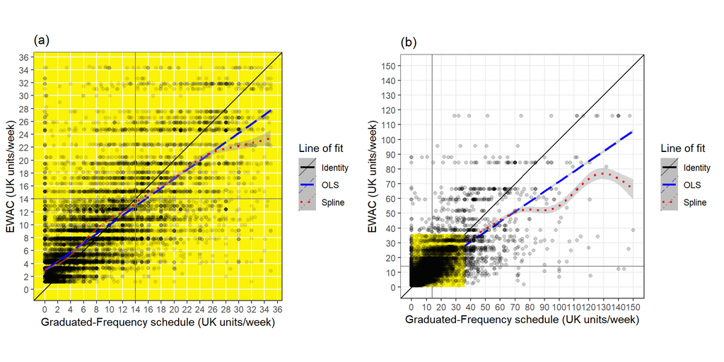

Figure 1: Plots of EWAC against GF in (a) low/increasing risk respondents (n=15,008) and (b) all respondents (n=15,731)

Extensive subgroup analyses are reported in supplementary material 5. A very modest proportion of variation in bias and precision (<5%) can be attributed to socio-demographic variables under examination. This indicates a relative homogeneity in precision in bias, to one exception. The EWAC appears to overestimate consumption by 1 to 2 UK units in groups with the lowest average consumption: women, and Non-British White, Black, and Other ethnic groups.

## Receiver Operating Characteristics

We examined the EWAC’s ability to predict consumption exceeding 14 or 35 UK units/week. The full areas under the receiver operating characteristic curves (AUC, supplementary Figure S6) are presented along sensitivity and specificity at the best thresholds in Tables 3–4.

Table 3: Receiver operating characteristics of AUDIT-C score and EWAC for consumption >= 14 UK units or 112g/week (n = 15,731)

[output not shown]

*Note*: The best threshold refers the cut-off value that maximises the sum of sensitivity and specificity.

**35 units/week (higher-risk)**: EWAC provides small increases in AUC compared with the AUDIT-C score ($p$ < 0.001) and the full AUDIT score ($p$ < 0.001). The best cut-off for detecting consumption in excess of 35 units/week using the EWAC was 17 units/week (Table 4).

Table 4: Receiver operating characteristics of AUDIT-C score and EWAC for consumption >= 35 UK units or 280g/week (n = 15,731)

| Index test | AUC | 95% CI | Best threshold | Sensitivity | Specificity |
| --- | --- | --- | --- | --- | --- |
| AUDIT-C score | 0.912 | [0.902, 0.922] | 6.5 | 0.862 | 0.810 |
| Full AUDIT score | 0.900 | [0.89, 0.91] | 6.5 | 0.905 | 0.743 |
| EWAC | 0.934 | [0.925, 0.943] | 16.8 | 0.862 | 0.865 |

*Note*: The best threshold refers the cut-off value that maximises the sum of sensitivity and specificity.

## Empirical distribution

Table 5 estimates adult residents’ total alcohol consumption in England using four different sources, and compares them with alcohol retail sales. The Health Survey for England exhibits the highest estimates and coverage of alcohol sales. EWAC amounts to 71% of the total consumption estimated by the Health Survey for England’s prospective diary, and 48% of retail sales.

Table 5: Summary statistics on alcohol consumption in England in residents aged 18 years and over (excluding abstainers)

| Study | Mean (units/week) | Median | Variance | N | % of alcohol sold |
| --- | --- | --- | --- | --- | --- |
| Health Survey for England beverage-specific QF | 14.0 | 7.3 | 474.6 | 6,545 | 72.6 |
| Health Survey for England prospective diary | 13.0 | 8.0 | 264.7 | 4,640 | 67.6 |
| Alcohol Toolkit Study GF | 8.5 | 5.2 | 234.6 | 15,556 | 43.9 |
| Alcohol Toolkit Study EWAC | 9.3 | 5.2 | 145.9 | 18,140 | 48.2 |
| Retail sales | 19.3 | – | – | – | – |

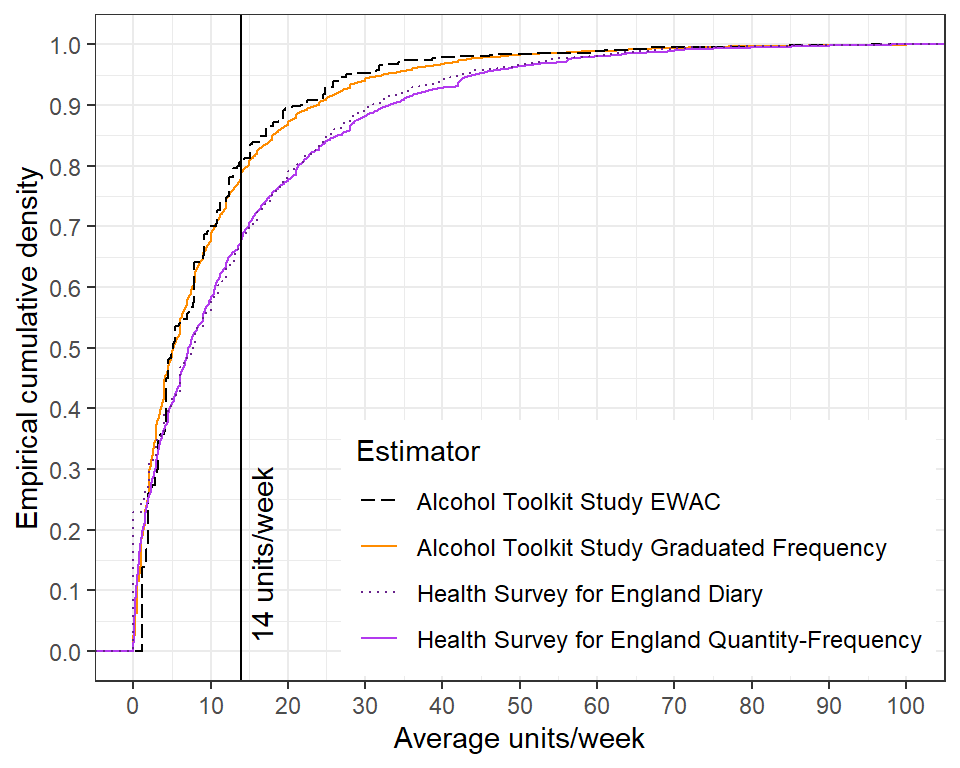

Figure 2: Empirical cumulative distribution function of weekly alcohol consumption in England according to four alcohol schedules in residents aged 18 years and over

# Discussion

## Main findings

We developed a continuous Estimator of Weekly Alcohol Consumption (EWAC) using a 6-month Extended AUDIT-C. When compared with a 4-week Graduated Frequency (GF) reference standard, we found EWAC overestimates alcohol consumption by 0.2 UK units [0.08, 0.4], well under the pre-registered ±1 UK unit bias tolerance. We also attempted to measure how precise the EWAC is: in 50% of participants, the EWAC falls up to 2 UK units away from the GF measure, and an interval built as EWAC ±50% contains the GF measures in 58% of participants.

## Potential applications

Being equivalent to the AUDIT-C in speed and international standardisation, the EWAC may be suitable for use in clinical practice to support brief interventions and to feed back a reliable interval estimate of alcohol consumption (eg: ‘6–18 units/week’ or ‘50–140g/week’). The EWAC is available as a web app at https://ewac.netlify.app along with resources to facilitate implementation (R software package, spreadsheets).

Assessment of alcohol consumption is not well embedded in clinical practice [40]. The EWAC calculator fills a gap in resources by transforming the answers from the Extended AUDIT-C into a direct estimate of an individual’s weekly alcohol consumption. This is a more directly accessible metric which should facilitate behaviour change by empowering people to monitor and control their alcohol consumption with–or without–the involvement of healthcare professionals, and should be assessed in future evaluations.

Nutt, Rehm *et al.* [19,41] argued that alcohol-related harm is best prevented if individuals know their consumption level, and health professionals in all settings can engage patients effectively to manage risks with evidence-based interventions, in a similar way to other risk factors for disease, for example blood pressure or cholesterol. Yet, knowledge of beverages’ alcohol content is generally poor [42], and a survey evaluating the 2016 change in UK alcohol guidelines found that just 8% of the UK drinkers knew the new recommended limits [43]. The EWAC can support interventions focused on recognising the alcohol content/volume of drinks, and recommended low-risk limits.

In addition, the EWAC’s dimensional rather than categorical format can be useful to position recipients of brief interventions on the continuum of alcohol use [20,44], which may reduce the stigma of loss of control associated with screening-based interventions [17,45]. It can act as a complement, rather than a substitute to the multidimensional quality of AUDIT-C or the full AUDIT.

The EWAC is particularly suitable for digital interventions and healthcare records given that it enables its complex algorithm to be embedded in a way not possible with paper records. EWAC is already compatible with medical records information models developed in the Systematised Nomenclature of Medicine Clinical Terms (SNOMED CT, Alcohol intake (observable entity) [46]) and by the English Royal College of Physicians [47]. Such information can have secondary uses as a variable in other disease risk scores, or to prospectively recording of long-term alcohol exposure, an important risk factor for a range of medical conditions.

## Strengths and limitations

This paper is the first to (a) develop an EWAC using a well-accepted and validated multidimensional alcohol screening tool such as the AUDIT; and (b) quantify its bias and precision with respect to a continuous measure of alcohol consumption. One study [48] previously reported mean consumption by AUDIT-C score, but without quantifying bias or precision of such a measure. Others have evaluated the AUDIT-C’s accuracy in estimating alcohol consumption, but exclusively in relation to predicting consumption in excess of predefined thresholds [11].

Our study provides strong confidence in the internal and external validity of findings in England on account of the large sample size and extensive range of subgroup analyses reported. Bias was mostly consistent across subgroups examined (age/sex, education, smoking status, religion), with one exception. EWAC overestimated alcohol consumption by 2-3 UK units/week in Black/Other ethnic groups. Variation in the sensitivity of AUDIT-C across ethnic groups has previously been noted in the US [49].

Repurposing a well-known tool such as the AUDIT-C has several advantages. It is already translated in many languages and adapted to the varying standard drink sizes adopted internationally [7]. The Extended AUDIT scores can be converted into traditional AUDIT scores by capping items to 4, thereby offering a point of comparison with existing evidence. The AUDIT’s properties are also well understood in diverse contexts and modes of administration, based on the last 30 years of international research. For instance, a previous study which found the AUDIT-C to be responsive to changes of 70g/week [50] can suggest that the EWAC’s own responsiveness to change should be equivalent, if not greater than the AUDIT-C’s, given the Extended AUDIT-C’s additional response items.

We note two main study limitations. First, a longstanding obstacle in alcohol research and treatment lies in the absence of undisputed ‘gold standard’ or biomarker for objectively determining alcohol consumption. Instead, a number of instruments measure self-reported consumption with varying validity and reliability over different durations. Comprehensive reviews [30–32,51–53] indicate that yesterday recall and prospective diaries tend to record higher (and more accurate) alcohol consumption by minimising recall bias, followed by GF measures.

Therefore, the GF reference standard, as all self-reported measures, is imperfect. While this has no effect on our measure of bias (MD), this may introduce bias into our measure of precision (RMSD): by definition, the reference standard’s own independent error will inflate the RMSD. In other words, it is likely that a proportion of the RMSD is attributable to error in the GF measures rather than the EWAC.

Despite this, previous research suggests the EWAC’s agreement with GF (Pearson’s correlation coefficient $r$ = 0.71 and Kendall’s rank correlation $\tau$ = 0.63 in the present study) is comparable to the agreement between GF and prospective diaries measured from past studies($r$ ~ 0.86–0.89 [54,55]; $\tau$ = 0.41 [51]).

Second, the EWAC’s design does not escape all limitations of methods of screening or categorising alcohol use disorders. The conceptualisation of alcohol use disorders is related to, but does not exclusively depend upon the amount of alcohol consumed. Since Jellinek’s description of ‘the disease concept of alcoholism’ [56] there have been numerous attempts to categorise the range of phenotypes characterising alcohol use disorders in the absence of any biomarker to ‘verify’ the presence of a particular pathology. The EWAC, by limiting itself to an estimation of alcohol consumption is transparent across a wide range of alcohol use disorders but does not measure the other factors underpinning this complex and heterogeneous condition [6,57].

In conclusion, the EWAC has the potential to support interventions focusing on recognising the alcohol content and volume of drinks. The EWAC’s dimensional rather than categorical format may facilitate this while avoiding the stigma sometimes associated with clinical categorisations of alcohol use disorders.

# Declarations

## Acknowledgements

This research was supported by the Medical Research Council [grant reference MR/P016960/1]. The Alcohol Toolkit Study data collection was funded primarily by the National Institute for Health Research (NIHR) School for Public Health Research [grant reference SPHR‐SWP‐ALC‐WP5] and Public Health Research Programme [grant reference 15/63/01]. The EWAC online calculator development was funded by the Wessex Academic Health Science Network. The views expressed are those of the author(s) and not necessarily those of the NHS, the NIHR or the Department of Health.

## Ethics

This study was approved by the University of Southampton’s Faculty of Medicine Ethics Committee (ERGO 44682).

## Consent for publication

Not applicable.

## Competing interests

JB has received unrestricted research funding to study smoking cessation from companies who manufacture smoking cessation medications. PD, JH and JMAS declare no competing interests.

# Supplementary information

## Supplementary information S1: Bayesian model report (PDF file)

There results being very similar, multiple imputation was not employed in the study.

## Supplementary information S2: Alcohol Toolkit Study Extended AUDIT questionnaire schedule

## Supplementary information S3: Alcohol Toolkit Study Graduated-Frequency questionnaire schedule

## Supplementary Table S4: EWAC coefficients (CSV file)

## Supplementary information S5: Analysis of subgroup variation in bias and error

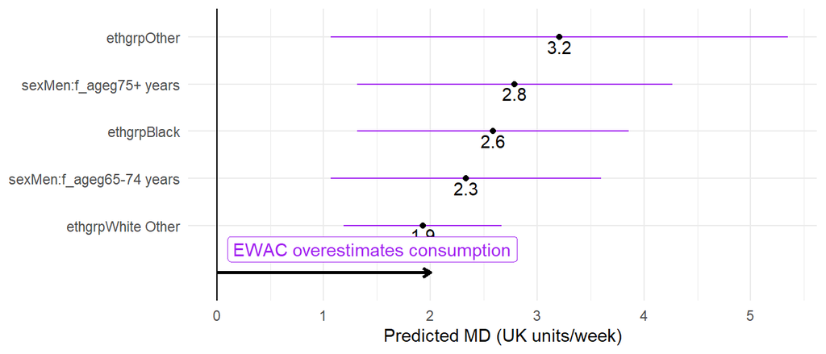

*Figure S5.1:* Forest plot of modelled MD for selected subgroups

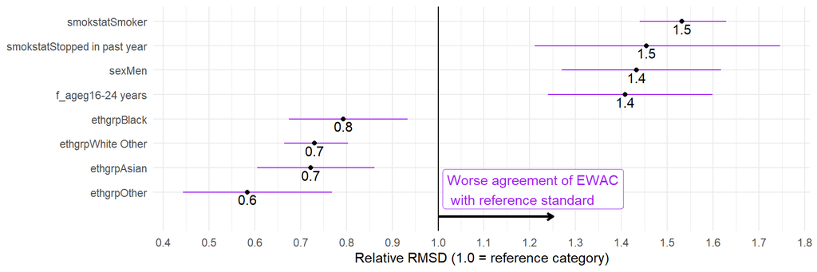

*Figure S5.2:* Forest plot of RMSD ratio (selected subgroups to reference category)

Figure S5.3 presents the same metrics for increasing-/higher-risk drinkers (AUDIT-C $\geq$ 5 or AUDIT $\geq$ 8). Educational qualifications significantly improved the agreement between EWAC and the reference standard in this group (Table S5.2). School and degree-level qualifications reduced RMSD by 22% [12%, 31%] and 28% [19%, 37%] respectively, suggesting that respondents may have better recall and clarity over alcohol beverage content.

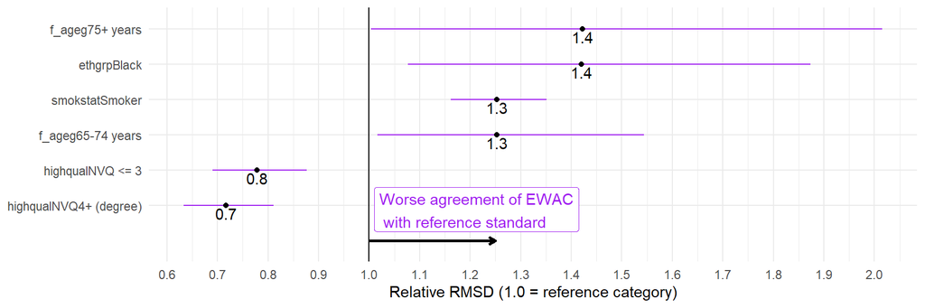

*Figure S5.3:* Forest plot of RMSD ratio (selected subgroups to reference category) in respondents with a hazardous/harmful alcohol use (AUDIT-C>=5 or AUDIT>=8)

Table S5.1: Coefficients of linear regression of subgroup bias and error of EWAC compared with GF in all respondents (n = 15,373)

|  | (EWAC_QFV - GFMEANWEEKLY) | LOG((EWAC_QFV - GFMEANWEEKLY)2) |
| --- | --- | --- |
|  | 1 | 2 |
| Constant | 0.9 (-0.01, 1.9) | 0.7 (0.5, 1.0)*** |
| sexMen | -1.1 (-2.0, -0.1)* | 0.7 (0.5, 1.0)*** |
| f_ageg16-24 years | 0.9 (-0.1, 1.9) | 0.7 (0.4, 0.9)*** |
| f_ageg35-44 years | -0.4 (-1.3, 0.6) | 0.1 (-0.2, 0.3) |
| f_ageg45-54 years | -0.2 (-1.1, 0.7) | 0.2 (-0.03, 0.4) |
| f_ageg55-64 years | 0.4 (-0.5, 1.3) | 0.1 (-0.1, 0.4) |
| f_ageg65-74 years | -0.3 (-1.2, 0.7) | -0.2 (-0.5, 0.02) |
| f_ageg75+ years | -0.8 (-2.0, 0.3) | -0.2 (-0.5, 0.1) |
| ethgrpWhite Other | 1.0 (0.3, 1.7)** | -0.6 (-0.8, -0.4)*** |
| ethgrpMixed | -0.5 (-2.0, 0.9) | -0.3 (-0.7, 0.1) |
| ethgrpAsian | 1.3 (-0.1, 2.7) | -0.7 (-1.0, -0.3)*** |
| ethgrpBlack | 1.7 (0.4, 2.9)* | -0.5 (-0.8, -0.1)** |
| ethgrpOther | 2.3 (0.1, 4.4)* | -1.1 (-1.6, -0.5)*** |
| religionChristian | 0.04 (-0.3, 0.4) | -0.2 (-0.3, -0.1)*** |
| religionMuslim | 0.5 (-2.4, 3.5) | -0.5 (-1.3, 0.2) |
| religionAny other religion | -0.7 (-1.7, 0.3) | -0.1 (-0.3, 0.2) |
| highqualNVQ < = 3 | -0.1 (-0.8, 0.5) | 0.02 (-0.1, 0.2) |
| highqualNVQ4+ (degree) | -0.2 (-0.9, 0.4) | 0.1 (-0.1, 0.3) |
| highqualOther | -0.1 (-0.9, 0.8) | 0.1 (-0.1, 0.3) |
| smokstatStopped> 1y ago | -0.1 (-0.5, 0.4) | 0.4 (0.3, 0.5)*** |
| smokstatStopped in past year | -0.6 (-2.1, 0.8) | 0.7 (0.4, 1.1)*** |
| smokstatSmoker | -0.7 (-1.2, -0.2)** | 0.9 (0.7, 1.0)*** |
| sexMen:f_ageg16-24 years | -0.5 (-1.9, 0.8) | -0.2 (-0.5, 0.1) |
| sexMen:f_ageg35-44 years | -0.5 (-1.8, 0.8) | -0.04 (-0.4, 0.3) |
| sexMen:f_ageg45-54 years | -0.7 (-2.0, 0.6) | 0.1 (-0.2, 0.4) |
| sexMen:f_ageg55-64 years | -0.1 (-1.4, 1.1) | 0.1 (-0.2, 0.5) |
| sexMen:f_ageg65-74 years | 1.4 (0.1, 2.7)* | 0.3 (0.02, 0.7)* |
| sexMen:f_ageg75+ years | 1.9 (0.4, 3.3)* | -0.3 (-0.7, 0.1) |
| Observations | 15,373 | 15,373 |
| R<sup>2</sup> | 0.01 | 0.05 |
| Adjusted R<sup>2</sup> | 0.01 | 0.05 |
| Residual Std. Error (df = 15345) | 10.7 | 2.7 |
| F Statistic (df = 27; 15345) | 4.1*** | 29.2*** |
| *Notes:* | *P < .05 |  |
|  | **P < .01 |  |
|  | ***P < .001 |  |

Table S5.2: Coefficients of linear regression of the subgroup bias and error of EWAC compared with GF in respondents with a hazardous/harmful alcohol use (AUDIT-C>=5 or AUDIT>=8; (n = 6,909)

|  | (EWAC_QFV - GFMEANWEEKLY) |  |
| --- | --- | --- |
|  | 1 | 2 |
| Constant | 0.5 (-1.6, 2.5) | 0.5 (-1.6, 2.5) |
| sexMen | -1.1 (-3.0, 0.8) | -1.1 (-3.0, 0.8) |
| f_ageg16-24 years | 1.1 (-0.8, 3.0) | 1.1 (-0.8, 3.0) |
| f_ageg35-44 years | -0.4 (-2.4, 1.6) | -0.4 (-2.4, 1.6) |
| f_ageg45-54 years | 0.3 (-1.6, 2.2) | 0.3 (-1.6, 2.2) |
| f_ageg55-64 years | 2.6 (0.6, 4.6)* | 2.6 (0.6, 4.6)* |
| f_ageg65-74 years | 1.1 (-1.2, 3.5) | 1.1 (-1.2, 3.5) |
| f_ageg75+ years | 5.2 (1.2, 9.1)* | 5.2 (1.2, 9.1)* |
| ethgrpWhite Other | 1.6 (-0.01, 3.2) | 1.6 (-0.01, 3.2) |
| ethgrpMixed | -1.4 (-4.3, 1.4) | -1.4 (-4.3, 1.4) |
| ethgrpAsian | 2.8 (-0.6, 6.3) | 2.8 (-0.6, 6.3) |
| ethgrpBlack | 4.2 (1.1, 7.3)** | 4.2 (1.1, 7.3)** |
| ethgrpOther | 5.4 (0.3, 10.5)* | 5.4 (0.3, 10.5)* |
| religionChristian | 0.2 (-0.5, 0.9) | 0.2 (-0.5, 0.9) |
| religionMuslim | 2.2 (-8.6, 13.1) | 2.2 (-8.6, 13.1) |
| religionAny other religion | -2.5 (-4.5, -0.4)* | -2.5 (-4.5, -0.4)* |
| highqualNVQ < = 3 | 0.7 (-0.7, 2.0) | 0.7 (-0.7, 2.0) |
| highqualNVQ4+ (degree) | 0.5 (-0.9, 1.9) | 0.5 (-0.9, 1.9) |
| highqualOther | 0.1 (-1.7, 1.9) | 0.1 (-1.7, 1.9) |
| smokstatStopped> 1y ago | -0.5 (-1.4, 0.3) | -0.5 (-1.4, 0.3) |
| smokstatStopped in past year | -1.0 (-3.5, 1.4) | -1.0 (-3.5, 1.4) |
| smokstatSmoker | -1.4 (-2.3, -0.6)** | -1.4 (-2.3, -0.6)** |
| favdrinkCider | -0.6 (-2.2, 1.0) | -0.6 (-2.2, 1.0) |
| favdrinkMixed spirits | 1.2 (-0.3, 2.7) | 1.2 (-0.3, 2.7) |
| favdrinkOther | 4.5 (0.4, 8.6)* | 4.5 (0.4, 8.6)* |
| favdrinkSpirits alone | 1.2 (-0.1, 2.6) | 1.2 (-0.1, 2.6) |
| favdrinkWine | 0.5 (-0.4, 1.4) | 0.5 (-0.4, 1.4) |
| tryalclyc2Attempt to cut down in last 12 months | -0.9 (-1.6, -0.1)* | -0.9 (-1.6, -0.1)* |
| sexMen:f_ageg16-24 years | -0.9 (-3.3, 1.6) | -0.9 (-3.3, 1.6) |
| sexMen:f_ageg35-44 years | -1.4 (-4.0, 1.1) | -1.4 (-4.0, 1.1) |
| sexMen:f_ageg45-54 years | -1.4 (-3.8, 1.1) | -1.4 (-3.8, 1.1) |
| sexMen:f_ageg55-64 years | -1.6 (-4.1, 0.9) | -1.6 (-4.1, 0.9) |
| sexMen:f_ageg65-74 years | 1.1 (-1.7, 3.9) | 1.1 (-1.7, 3.9) |
| sexMen:f_ageg75+ years | -2.3 (-6.7, 2.2) | -2.3 (-6.7, 2.2) |
| Observations | 6,909 | 6,909 |
| R<sup>2</sup> | 0.02 | 0.02 |
| Adjusted R<sup>2</sup> | 0.02 | 0.02 |
| Residual Std. Error (df = 6875) | 14.1 | 14.1 |
| F Statistic (df = 33; 6875) | 4.3*** | 4.3*** |
| *Notes:* | *P < .05 |  |
|  | **P < .01 |  |
|  | ***P < .001 |  |

## Supplementary information S6: Receiver operating characteristics curves

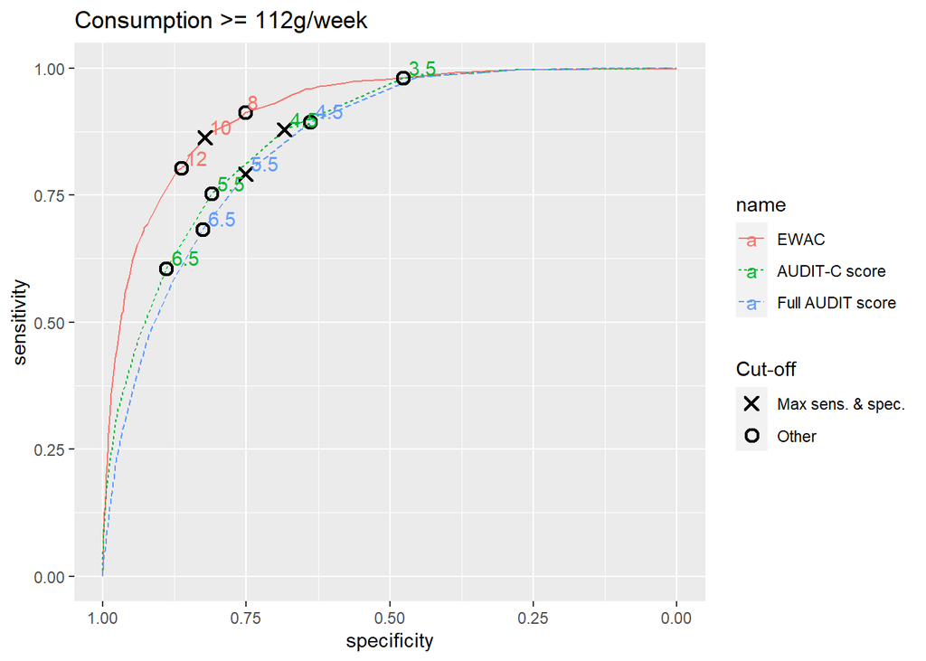

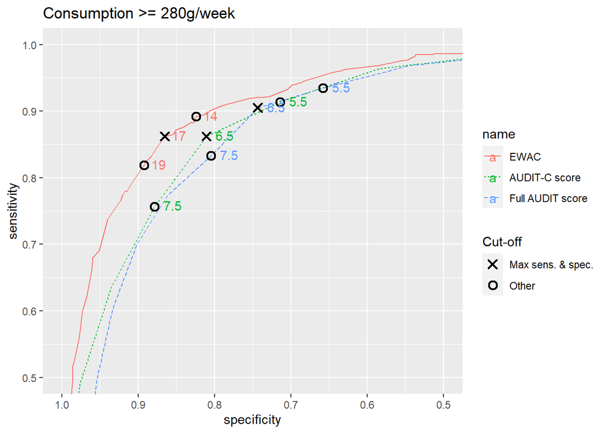

## Supplementary information S7: Demographic characteristics and alcohol consumption descriptives

|  | <14 (N=17402) | 14-34 (N=3932) | 35-50 (N=582) | 50-400 (N=483) | Missing (N=4017) | Never drinks (AUDIT-1 = 0) (N=14399) | Total (N=40815) |
| --- | --- | --- | --- | --- | --- | --- | --- |
| **Gender** |  |  |  |  |  |  |  |
| Women | 8713 (50.1%) | 1200 (30.5%) | 124 (21.3%) | 104 (21.5%) | 2200 (54.8%) | 7996 (55.5%) | 20337 (49.8%) |
| Men | 8689 (49.9%) | 2732 (69.5%) | 458 (78.7%) | 379 (78.5%) | 1817 (45.2%) | 6403 (44.5%) | 20478 (50.2%) |
| **Age** |  |  |  |  |  |  |  |
| N-Miss | 69 | 10 | 1 | 2 | 51 | 154 | 287 |
| 16-24 years | 2246 (13.0%) | 491 (12.5%) | 72 (12.4%) | 56 (11.6%) | 671 (16.9%) | 2383 (16.7%) | 5919 (14.6%) |
| 25-34 years | 2320 (13.4%) | 394 (10.0%) | 57 (9.8%) | 43 (8.9%) | 582 (14.7%) | 2400 (16.8%) | 5796 (14.3%) |
| 35-44 years | 2378 (13.7%) | 463 (11.8%) | 57 (9.8%) | 71 (14.8%) | 514 (13.0%) | 2243 (15.7%) | 5726 (14.1%) |
| 45-54 years | 2852 (16.5%) | 678 (17.3%) | 124 (21.3%) | 95 (19.8%) | 529 (13.3%) | 1845 (13.0%) | 6123 (15.1%) |
| 55-64 years | 2946 (17.0%) | 792 (20.2%) | 104 (17.9%) | 122 (25.4%) | 570 (14.4%) | 1808 (12.7%) | 6342 (15.6%) |
| 65-74 years | 2831 (16.3%) | 767 (19.6%) | 132 (22.7%) | 73 (15.2%) | 622 (15.7%) | 1828 (12.8%) | 6253 (15.4%) |
| 75+ years | 1760 (10.2%) | 337 (8.6%) | 35 (6.0%) | 21 (4.4%) | 478 (12.1%) | 1738 (12.2%) | 4369 (10.8%) |
| **Ethnic group** |  |  |  |  |  |  |  |
| N-Miss | 64 | 10 | 0 | 2 | 14 | 92 | 182 |
| White British | 15080 (87.0%) | 3673 (93.7%) | 552 (94.8%) | 445 (92.5%) | 3310 (82.7%) | 8637 (60.4%) | 31697 (78.0%) |
| White Other | 1147 (6.6%) | 133 (3.4%) | 15 (2.6%) | 18 (3.7%) | 327 (8.2%) | 1166 (8.1%) | 2806 (6.9%) |
| Mixed | 226 (1.3%) | 47 (1.2%) | 7 (1.2%) | 7 (1.5%) | 53 (1.3%) | 217 (1.5%) | 557 (1.4%) |
| Asian | 385 (2.2%) | 27 (0.7%) | 4 (0.7%) | 7 (1.5%) | 135 (3.4%) | 2901 (20.3%) | 3459 (8.5%) |
| Black | 372 (2.1%) | 28 (0.7%) | 2 (0.3%) | 2 (0.4%) | 146 (3.6%) | 1065 (7.4%) | 1615 (4.0%) |
| Other | 128 (0.7%) | 14 (0.4%) | 2 (0.3%) | 2 (0.4%) | 32 (0.8%) | 321 (2.2%) | 499 (1.2%) |
| **Highest qualification** |  |  |  |  |  |  |  |
| N-Miss | 71 | 7 | 2 | 1 | 30 | 109 | 220 |
| No qualification | 1692 (9.8%) | 349 (8.9%) | 57 (9.8%) | 69 (14.3%) | 681 (17.1%) | 3203 (22.4%) | 6051 (14.9%) |
| NVQ <= 3 | 8086 (46.7%) | 1796 (45.8%) | 284 (49.0%) | 247 (51.2%) | 2020 (50.7%) | 6677 (46.7%) | 19110 (47.1%) |
| NVQ4+ (degree) | 6405 (37.0%) | 1504 (38.3%) | 199 (34.3%) | 135 (28.0%) | 952 (23.9%) | 3238 (22.7%) | 12433 (30.6%) |
| Other | 1148 (6.6%) | 276 (7.0%) | 40 (6.9%) | 31 (6.4%) | 334 (8.4%) | 1172 (8.2%) | 3001 (7.4%) |
| **AUDIT-C score** |  |  |  |  |  |  |  |
| N-Miss | 25 | 2 | 2 | 2 | 143 | 0 | 174 |
| [0,1) | 0 (0.0%) | 0 (0.0%) | 0 (0.0%) | 0 (0.0%) | 0 (0.0%) | 14399 (100.0%) | 14399 (35.4%) |
| [1,5) | 11895 (68.5%) | 550 (14.0%) | 19 (3.3%) | 19 (4.0%) | 3106 (80.2%) | 0 (0.0%) | 15589 (38.4%) |
| [5,8) | 4418 (25.4%) | 1856 (47.2%) | 136 (23.4%) | 76 (15.8%) | 578 (14.9%) | 0 (0.0%) | 7064 (17.4%) |
| [8,12] | 1064 (6.1%) | 1524 (38.8%) | 425 (73.3%) | 386 (80.2%) | 190 (4.9%) | 0 (0.0%) | 3589 (8.8%) |
| **Full AUDIT score** |  |  |  |  |  |  |  |
| N-Miss | 29 | 8 | 3 | 6 | 150 | 5 | 201 |
| [0,1) | 0 (0.0%) | 0 (0.0%) | 0 (0.0%) | 0 (0.0%) | 0 (0.0%) | 14050 (97.6%) | 14050 (34.6%) |
| [1,8) | 15221 (87.6%) | 1897 (48.3%) | 104 (18.0%) | 67 (14.0%) | 3489 (90.2%) | 340 (2.4%) | 21118 (52.0%) |
| [8,16) | 2036 (11.7%) | 1846 (47.0%) | 403 (69.6%) | 239 (50.1%) | 322 (8.3%) | 4 (0.0%) | 4850 (11.9%) |
| [16,20) | 93 (0.5%) | 129 (3.3%) | 51 (8.8%) | 73 (15.3%) | 23 (0.6%) | 0 (0.0%) | 369 (0.9%) |
| [20,40] | 23 (0.1%) | 52 (1.3%) | 21 (3.6%) | 98 (20.5%) | 33 (0.9%) | 0 (0.0%) | 227 (0.6%) |
| **Favourite drink** |  |  |  |  |  |  |  |
| N-Miss | 11782 | 529 | 20 | 20 | 3208 | 14395 | 29954 |
| Beer | 2218 (39.5%) | 1493 (43.9%) | 259 (46.1%) | 228 (49.2%) | 334 (41.3%) | 1 (25.0%) | 4533 (41.7%) |
| Cider | 318 (5.7%) | 119 (3.5%) | 30 (5.3%) | 42 (9.1%) | 62 (7.7%) | 0 (0.0%) | 571 (5.3%) |
| Mixed spirits | 402 (7.2%) | 165 (4.8%) | 14 (2.5%) | 21 (4.5%) | 71 (8.8%) | 0 (0.0%) | 673 (6.2%) |
| Other | 57 (1.0%) | 12 (0.4%) | 4 (0.7%) | 1 (0.2%) | 16 (2.0%) | 2 (50.0%) | 92 (0.8%) |
| Spirits alone | 473 (8.4%) | 227 (6.7%) | 44 (7.8%) | 49 (10.6%) | 150 (18.5%) | 0 (0.0%) | 943 (8.7%) |
| Wine | 2152 (38.3%) | 1387 (40.8%) | 211 (37.5%) | 122 (26.3%) | 176 (21.8%) | 1 (25.0%) | 4049 (37.3%) |
| **Attempt to cut down** |  |  |  |  |  |  |  |
| N-Miss | 11781 | 529 | 20 | 19 | 3204 | 14395 | 29948 |
| No attempt to cut down | 4302 (76.5%) | 2453 (72.1%) | 400 (71.2%) | 316 (68.1%) | 642 (79.0%) | 2 (50.0%) | 8115 (74.7%) |
| Attempt to cut down in last 12 months | 1319 (23.5%) | 950 (27.9%) | 162 (28.8%) | 148 (31.9%) | 171 (21.0%) | 2 (50.0%) | 2752 (25.3%) |

## Supplementary information S8: STARD Checklist

# References

[1] Shield K, Manthey J, Rylett M, Probst C, Wettlaufer A, Parry CDH, et al. National, regional, and global burdens of disease from 2000 to 2016 attributable to alcohol use: a comparative risk assessment study. The Lancet Public Health 2020;5:e51–61. doi:10.1016/S2468-2667(19)30231-2.

[2] World Health Organisation. ICD-10: International statistical classification of diseases and related health problems: Tenth revision. 2004.

[3] American Psychiatric Association. Diagnostic and Statistical Manual of Mental Disorders. Washington, DC: American Psychiatric Association; 2013. doi:10.1176/appi.books.9780890425596.

[4] Health NI of, Excellence C. Alcohol-use disorders: prevention. Public health guideline [PH24]. 2010.

[5] National Institute of Health and Care Excellence. Alcohol-use disorders: diagnosis, assessment and management of harmful drinking and alcohol dependence. Clinical guideline [CG115]. 2011.

[6] Saunders JB, Degenhardt L, Reed GM, Poznyak V. Alcohol Use Disorders in ICD‐11: Past, Present, and Future. Alcoholism: Clinical and Experimental Research 2019;43:1617–31. doi:10.1111/acer.14128.

[7] Babor TF, Higgins-Biddle JC, Saunders JB, Monteiro MG. The Alcohol Use Disorders Identification Test. Guidelines for Use in Primary Care. Second Edition. Geneva: World Health Organisation, Department of Mental Health; Substance Dependence; 2001.

[8] Bush K. The AUDIT Alcohol Consumption Questions (AUDIT-C): An Effective Brief Screening Test for Problem Drinking. Archives of Internal Medicine 1998;158:1789. doi:10.1001/archinte.158.16.1789.

[9] Kaner EF, Beyer FR, Muirhead C, Campbell F, Pienaar ED, Bertholet N, et al. Effectiveness of brief alcohol interventions in primary care populations. Cochrane Database of Systematic Reviews 2018. doi:10.1002/14651858.CD004148.pub4.

[10] Kaner EF, Beyer FR, Garnett C, Crane D, Brown J, Muirhead C, et al. Personalised digital interventions for reducing hazardous and harmful alcohol consumption in community-dwelling populations. Cochrane Database of Systematic Reviews 2017. doi:10.1002/14651858.CD011479.pub2.

[11] Meneses-Gaya C de, Zuardi AW, Loureiro SR, Crippa JAS. Alcohol Use Disorders Identification Test (AUDIT): An updated systematic review of psychometric properties. Psychology & Neuroscience 2009;2:83–97. doi:10.3922/j.psns.2009.1.12.

[12] Nadkarni A, Garber A, Costa S, Wood S, Kumar S, MacKinnon N, et al. Auditing the AUDIT: A systematic review of cut-off scores for the Alcohol Use Disorders Identification Test (AUDIT) in low- and middle-income countries. Drug and Alcohol Dependence 2019;202:123–33. doi:10.1016/j.drugalcdep.2019.04.031.

[13] Beich A, Gannik D, Malterud K. Screening and brief intervention for excessive alcohol use: Qualitative interview study of the experiences of general practitioners. BMJ 2002;325:870–0. doi:10.1136/bmj.325.7369.870.

[14] Johnson M, Jackson R, Guillaume L, Meier P, Goyder E. Barriers and facilitators to implementing screening and brief intervention for alcohol misuse: a systematic review of qualitative evidence. Journal of Public Health (Oxford, England) 2011;33:412–21. doi:10.1093/pubmed/fdq095.

[15] Hutchings D, Cassidy P, Dallolio E, Pearson P, Heather N, Kaner E. Implementing screening and brief alcohol interventions in primary care: Views from both sides of the consultation. Primary Health Care Research and Development 2006;7:221–9. doi:10.1191/1463423606pc292oa.

[16] McCormick KA, Cochran NE, Back AL, Merrill JO, Williams EC, Bradley KA. How Primary Care Providers Talk to Patients About Alcohol. Journal of General Internal Medicine 2006:060721075157048. doi:10.1111/j.1525-1497.2006.00490.x.

[17] Khadjesari Z, Stevenson F, Toner P, Linke S, Milward J, Murray E. ’I’m not a real boozer’: A qualitative study of primary care patients’ views on drinking and its consequences. Journal of Public Health (Oxford, England) 2018:1–7. doi:10.1093/pubmed/fdy067.

[18] O’Donnell A, Hanratty B, Schulte B, Kaner E. Patients’ experiences of alcohol screening and advice in primary care: A qualitative study. BMC Family Practice 2020;21:68. doi:10.1186/s12875-020-01142-9.

[19] Nutt DJ, Rehm J. Doing it by numbers: A simple approach to reducing the harms of alcohol. Journal of Psychopharmacology 2014;28:3–7. doi:10.1177/0269881113512038.

[20] Rehm J, Marmet S, Anderson P, Gual A, Kraus L, Nutt DJ, et al. Defining Substance Use Disorders: Do We Really Need More Than Heavy Use? Alcohol and Alcoholism 2013;48:633–40. doi:10.1093/alcalc/agt127.

[21] Kaner E, Bland M, Cassidy P, Coulton S, Dale V, Deluca P, et al. Effectiveness of screening and brief alcohol intervention in primary care (SIPS trial): pragmatic cluster randomised controlled trial. BMJ 2013;346:e8501–1. doi:10.1136/bmj.e8501.

[22] Crane D, Garnett C, Michie S, West R, Brown J. A smartphone app to reduce excessive alcohol consumption: Identifying the effectiveness of intervention components in a factorial randomised control trial. Scientific Reports 2018;8:4384. doi:10.1038/s41598-018-22420-8.

[23] Beard E, Brown J, West R, Acton C, Brennan A, Drummond C, et al. Protocol for a national monthly survey of alcohol use in England with 6-month follow-up: ’The Alcohol Toolkit Study’ Health behavior, health promotion and society. BMC Public Health 2015;15. doi:10.1186/s12889-015-1542-7.

[24] Michie S, Whittington C, Hamoudi Z, Zarnani F, Tober G, West R. Identification of behaviour change techniques to reduce excessive alcohol consumption. Addiction 2012;107:1431–40. doi:10.1111/j.1360-0443.2012.03845.x.

[25] Greenfield TK. Ways of measuring drinking patterns and the difference they make: experience with graduated frequencies. Journal of Substance Abuse 2000;12:33–49. doi:10.1016/S0899-3289(00)00039-0.

[26] Public Health England. Alcohol sales in England in 2014: Analysis to assess suitability for inclusion as an indicator in the Local Alcohol Profiles for England. 2017.

[27] NatCen Social Research, Royal Free and University College Medical School. Health Survey for England, 2011 [computer file]. Colchester, Essex: UK Data Archive [distributor], April 2013. SN: 7260. Colchester, Essex: 2013. doi:10.5255/UKDA-SN-7260-1.

[28] Dutey-Magni P, Sinclair J, Brown J. Concurrent validity of an Estimator of Weekly Alcohol Consumption (EWAC) based on the Extended AUDIT 2018. doi:10.17605/OSF.IO/7WE4M.

[29] Boniface S, Kneale J, Shelton N. Drinking pattern is more strongly associated with under-reporting of alcohol consumption than socio-demographic factors: evidence from a mixed-methods study. BMC Public Health 2014;14:1297. doi:10.1186/1471-2458-14-1297.

[30] Stockwell T, Donath S, Cooper-Stanbury M, Chikritzhs T, Catalano P, Mateo C. Under-reporting of alcohol consumption in household surveys: A comparison of quantity-frequency, graduated-frequency and recent recall. Addiction 2004;99:1024–33. doi:10.1111/j.1360-0443.2004.00815.x.

[31] Stockwell T, Zhao J, Macdonald S. Who under-reports their alcohol consumption in telephone surveys and by how much? An application of the ’yesterday method’ in a national Canadian substance use survey. Addiction (Abingdon, England) 2014;109:1657–66. doi:10.1111/add.12609.

[32] Stockwell T, Zhao J, Greenfield T, Li J, Livingston M, Meng Y. Estimating under- and over-reporting of drinking in national surveys of alcohol consumption: identification of consistent biases across four English-speaking countries. Addiction 2016;111:1203–13. doi:10.1111/add.13373.

[33] Lemmens P, Tan ES, Knibbe R a. Measuring quantity and frequency of drinking in a general population survey: a comparison of five indices. Journal of Studies on Alcohol 1992;53:476–86. doi:10.15288/jsa.1992.53.476.

[34] R Core Team. R: A language and environment for statistical computing. Vienna, Austria: R Foundation for Statistical Computing; 2017.

[35] Wickham H. Tidyverse: Easily install and load the ’tidyverse’ 2017.

[36] Stan Development Team. RStan: The R interface to Stan 2018.

[37] Dutey-Magni P. Concurrent validity of an Estimator of Weekly Alcohol Consumption (EWAC) based on the Extended AUDIT: Computer scripts 2020. doi:10.5281/zenodo.4315024.

[38] Lavoie D. Alcohol identification and brief advice in England: A major plank in alcohol harm reduction policy. Drug and Alcohol Review 2010;29:608–11. doi:10.1111/j.1465-3362.2010.00224.x.

[39] DeLong ER, DeLong DM, Clarke-Pearson DL. Comparing the Areas under Two or More Correlated Receiver Operating Characteristic Curves: A Nonparametric Approach. Biometrics 1988;44:837. doi:10.2307/2531595.

[40] Brown J, West R, Angus C, Beard E, Brennan A, Drummond C, et al. Comparison of brief interventions in primary care on smoking and excessive alcohol consumption: A population survey in england. British Journal of General Practice 2016;66:e1–9. doi:10.3399/bjgp16X683149.

[41] Rehm J, Anderson P, Manthey J, Shield KD, Struzzo P, Wojnar M, et al. Alcohol Use Disorders in Primary Health Care: What Do We Know and Where Do We Go? Alcohol and Alcoholism 2016;51:422–7. doi:10.1093/alcalc/agv127.

[42] Mongan D, Long J. Standard drink measures throughout Europe; peoples’ understanding of standard drinks. RARHA: Joint Actional on Reducing Alcohol Related Harm; 2015.

[43] Rosenberg G, Bauld L, Hooper L, Buykx P, Holmes J, Vohra J. New national alcohol guidelines in the uk: Public awareness, understanding and behavioural intentions. Journal of Public Health 2018;40:549–56. doi:10.1093/pubmed/fdx126.

[44] Rehm J, Anderson P, Gual A, Kraus L, Marmet S, Nutt D, et al. The Tangible Common Denominator of Substance Use Disorders: A Reply to Commentaries to Rehm et al. (2013a). Alcohol and Alcoholism 2013;49:118–22. doi:10.1093/alcalc/agt171.

[45] O’Donnell A, Abidi L, Brown J, Karlsson N, Nilsen P, Roback K, et al. Beliefs and attitudes about addressing alcohol consumption in health care: A population survey in England. BMC Public Health 2018;18:391. doi:10.1186/s12889-018-5275-2.

[46] UK Health and Social Care Information Centre. UK SNOMED CT Drug Extension, RF2: Full, Snapshot & Delta 2018.

[47] Haroon S, Wooldridge D, Hoogewerf J, Mittal A, Bhala N, O’Donnell A, et al. Information standards for recording alcohol use in electronic health records: Project report 2018.

[48] Rubinsky AD, Dawson DA, Williams EC, Kivlahan DR, Bradley KA. AUDIT-C Scores as a Scaled Marker of Mean Daily Drinking, Alcohol Use Disorder Severity, and Probability of Alcohol Dependence in a U.S. General Population Sample of Drinkers. Alcoholism: Clinical and Experimental Research 2013;37:1380–90. doi:10.1111/acer.12092.

[49] Frank D, DeBenedetti AF, Volk RJ, Williams EC, Kivlahan DR, Bradley KA. Effectiveness of the AUDIT-C as a Screening Test for Alcohol Misuse in Three Race/Ethnic Groups. Journal of General Internal Medicine 2008;23:781–7. doi:10.1007/s11606-008-0594-0.

[50] Bradley KA, McDonell MB, Bush K, Kivlahan DR, Diehr P, Fihn SD. The AUDIT Alcohol Consumption Questions: Reliability, Validity, and Responsiveness to Change in Older Male Primary Care Patients. Alcoholism: Clinical and Experimental Research 1998;22:1842–9. doi:10.1111/j.1530-0277.1998.tb03991.x.

[51] Heeb J-L, Gmel G. Measuring alcohol consumption: A comparison of graduated frequency, quantity frequency, and weekly recall diary methods in a general population survey. Addictive Behaviors 2005;30:403–13. doi:10.1016/j.addbeh.2004.04.022.

[52] Livingston M, Callinan S. Underreporting in Alcohol Surveys: Whose Drinking Is Underestimated? Journal of Studies on Alcohol and Drugs 2015;76:158–64. doi:10.15288/jsad.2015.76.158.

[53] Rehm J. Measuring Quantity, Frequency, and Volume of Drinking. Alcoholism: Clinical and Experimental Research 1998;22:4s–14s. doi:10.1111/j.1530-0277.1998.tb04368.x.

[54] Greenfield TK, Kerr WC, Bond J, Ye Y, Stockwell T. Improving Graduated Frequencies Alcohol Measures for Monitoring Consumption Patterns: Results from an Australian National Survey and a US Diary Validity Study. Contemporary Drug Problems 2009;36:705–33. doi:10.1177/009145090903600320.

[55] Hilton ME. A comparison of a prospective diary and two summary recall techniques for recording alcohol consumption. British Journal of Addiction 1989;84:1085–92. doi:10.1111/j.1360-0443.1989.tb00792.x.

[56] Jellinek EM. The disease concept of alcoholism. New Haven: Hillhouse Press; 1960. doi:10.1037/14090-000.

[57] Leggio L, Kenna GA, Fenton M, Bonenfant E, Swift RM. Typologies of Alcohol Dependence. From Jellinek to Genetics and Beyond. Neuropsychology Review 2009;19:115–29. doi:10.1007/s11065-008-9080-z.